# PyTorch Tutorials by Morvan Zhou

Edited by Max Liu from 05/05 - 05/12/2019

> References:
> - [LaTeX Symbols](https://estudijas.lu.lv/pluginfile.php/14809/mod_page/content/16/instrukcijas/matematika_moodle/LaTeX_Symbols.pdf)
> - [PyTorch 教程系列 | 莫烦Python](https://morvanzhou.github.io/tutorials/machine-learning/torch/)

## List before

1. This is my first self-completement learning for PyTorch.
2. I get all my materials from MorvanZhou, and I appreciate him very much.
3. I did little changing in his codes in terms of self-learning.
4. If anything wrong with copyright, do please contact me!

## $\S1.\ Introduction$

I have learned about this part before, so I list some key ideas.

- 刺激形成神经元之间的连接
- 训练神经网络，调整参数，使部分神经元变得敏感
- 梯度下降，cost fuction可以简化为x^2的形式，不过convex的话就是全局最优。但一般局部最优也可以足够好
- 黑盒指的还是hidden layer，但是看某一层的时候，相当于在转换特征，即深度学习
- 试着学习下迁移学习
- PyTorch，神经网络领域numpy模块的替换。建立的是动态神经网络，而tensorflow是静态的（待问）。优劣不好说。
- 自己安装完成了。CUDA指GPU加速

## $\S2.\ PyTorch神经网络基础$

### $\S2.1\ Basic\ PyTorch$

$\bigstar$ Try codes personally.

```python
import torch
import numpy as np
```

```python
np_data = np.arange(6).reshape((2, 3))
torch_data = torch.from_numpy(np_data)# from numpy's array 2 tensor
print('numpy:\n', np_data, '\ntorch:\n', torch_data)
```

```
numpy:
 [[0 1 2]
 [3 4 5]]
torch:
 tensor([[0, 1, 2],
        [3, 4, 5]], dtype=torch.int32)
```

```python
# from tensor to numpy
tensor2array = torch_data.numpy()
print('\nnumpy:\n', tensor2array)
```

```
numpy:
 [[0 1 2]
 [3 4 5]]
```

```python
## operations
# abs
data = [-1, -2, 1, 2]
tensor = torch.FloatTensor(data) # 32 bit
print('numpy:\n', np.abs(data), '\ntorch:\n', torch.abs(tensor))
```

```
numpy:
 [1 2 1 2]
torch:
 tensor([1., 2., 1., 2.])
```

```python
# matrix is same
data = [[-1, 2], [-3, 4]]
tensor = torch.FloatTensor(data) # 32 bit
print('numpy:\n', np.abs(data), '\ntorch:\n', torch.abs(tensor))
```

```
numpy:
 [[1 2]
 [3 4]]
torch:
 tensor([[1., 2.],
        [3., 4.]])
```

```python
# operations for matrix
print('numpy:\n', np.matmul(data, data), '\nnumpy:\n', data.dot(data), '\ntorch:\n', tensor.dot(tensor))
```

```
---------------------------------------------------------------------------
AttributeError                            Traceback (most recent call last)
<ipython-input-18-5c6e34986fb2> in <module>
      1 # operations for matrix
----> 2 print('numpy:\n', np.matmul(data, data), '\nnumpy:\n', data.dot(data), '\ntorch:\n', tensor.dot(tensor))

AttributeError: 'list' object has no attribute 'dot'
```

```python
# need to change list to array!
print('numpy:\n', np.matmul(data, data), '\ntorch:\n', torch.mm(tensor, tensor))
data = np.array(data)
print('\nnumpy:\n', data.dot(data), '\ntorch:\n', tensor.dot(tensor))
```

```
numpy:
 [[-5  6]
 [-9 10]]
torch:
 tensor([[-5.,  6.],
        [-9., 10.]])
```

```
---------------------------------------------------------------------------
RuntimeError                              Traceback (most recent call last)
<ipython-input-19-1528408b7671> in <module>
      2 print('numpy:\n', np.matmul(data, data), '\ntorch:\n', torch.mm(tensor, tensor))
      3 data = np.array(data)
----> 4 print('\nnumpy:\n', data.dot(data), '\ntorch:\n', tensor.dot(tensor))

RuntimeError: dot: Expected 1-D argument self, but got 2-D
```

```python
# need to change to reshape
tensor = tensor.reshape((4))
print('torch:\n', tensor.dot(tensor))
```

```
torch:
 tensor(30.)
```

### $\S2.2\ Variable$

```python
from torch.autograd import Variable

tensor = torch.FloatTensor([[1, 2], [3, 4]])
variable = Variable(tensor, requires_grad = True)

print(tensor)
print(variable)

##################################
# 应该说目前深度学习的框架大部分都基于计算图谱
# 一张图大概可以看成一张有向无环图，图中的节点分为不同几种
# 其中一种就是variable，那么这个有什么用呢
# 所以我们要把一个tensor
# ……多打了个回车串行了））作为一个神经网络的参数，首先就要变成variable类型
# variable就是存放神经网络参数的东西，并且神经网络优化一般都是优化类型为variable的节点
# 这样才能被反向传播计算并且更新到
# 补充一下，剩下的几种常见节点类型有常量和占位符，这两种节点都不会被优化，由此可见variable节点才是神经网络的主体
##################################
```

```
tensor([[1., 2.],
        [3., 4.]])
tensor([[1., 2.],
        [3., 4.]], requires_grad=True)
```

```python
print(tensor * tensor)
t_out = torch.mean(tensor * tensor)
v_out = torch.mean(variable * variable)

print(t_out, '\n', v_out)
```

```
tensor([[ 1.,  4.],
        [ 9., 16.]])
tensor(7.5000)
 tensor(7.5000, grad_fn=<MeanBackward0>)
```

$\bigstar$ Only variable can be used in 反向传播 in old version.

$\bigstar$ However, now tensor can be use, too, wakakakakakakk.

$\bigstar$ So it's not so important now?? Not sure.

```python
t_out.backward()
print(tensor.grad)
```

```
---------------------------------------------------------------------------
RuntimeError                              Traceback (most recent call last)
<ipython-input-33-328aeec42617> in <module>
----> 1 t_out.backward()
      2 print(tensor.grad)

D:\Anaconda3\envs\py3\lib\site-packages\torch\tensor.py in backward(self, gradient, retain_graph, create_graph)
    105                 products. Defaults to ``False``.
    106         """
--> 107         torch.autograd.backward(self, gradient, retain_graph, create_graph)
    108
    109     def register_hook(self, hook):

D:\Anaconda3\envs\py3\lib\site-packages\torch\autograd\__init__.py in backward(tensors, grad_tensors, retain_graph, create_graph, grad_variables)
     91     Variable._execution_engine.run_backward(
     92         tensors, grad_tensors, retain_graph, create_graph,
---> 93         allow_unreachable=True)  # allow_unreachable flag
     94
     95

RuntimeError: element 0 of tensors does not require grad and does not have a grad_fn
```

```python
new_tensor = torch.FloatTensor([[1, 2], [3, 4]], requires_grad = True)
new_t_out = new_tensor * new_tensor
new_t_out.backward()
print(new_tensor.grad)
```

```
---------------------------------------------------------------------------
TypeError                                 Traceback (most recent call last)
<ipython-input-38-51ba296b1ad2> in <module>
----> 1 new_tensor = torch.FloatTensor([[1, 2], [3, 4]], requires_grad = True)
      2 new_t_out = new_tensor * new_tensor
      3 new_t_out.backward()
      4 print(new_tensor.grad)

TypeError: new() received an invalid combination of arguments - got (list, requires_grad=bool), but expected one of:
 * (torch.device device)
 * (torch.Storage storage)
 * (Tensor other)
 * (tuple of ints size, torch.device device)
      didn't match because some of the keywords were incorrect: requires_grad
 * (object data, torch.device device)
      didn't match because some of the keywords were incorrect: requires_grad
```

$\bigstar$ A bit sad, how can a tensor backward???

$\bigstar$ So many bugs.

$\bigstar$ Again search it, find:

```
The Variable API has been deprecated: Variables are no longer necessary to use autograd with tensors.
```

```python
tensor.requires_grad
```

```
False
```

```python
tensor.requires_grad = True
tensor.requires_grad
```

```
True
```

```python
t_out = torch.mean(tensor * tensor)
t_out.backward()
print(tensor.grad)
```

```
tensor([[0.5000, 1.0000],
        [1.5000, 2.0000]])
```

$\bigstar$ Problem solved, just use:

```
tensor.requires_grad = True
```

```python
v_out.backward()
print(variable.grad)
```

```
tensor([[0.5000, 1.0000],
        [1.5000, 2.0000]])
```

```python
# others variable has
print(variable.data)
print(variable.data.numpy())
```

```
tensor([[1., 2.],
        [3., 4.]])
[[1. 2.]
 [3. 4.]]
```

### $\S2.3\ Activation Function$

```python
import torch
import torch.nn.functional as F
import matplotlib.pyplot as plt

# fake data
x = torch.linspace(-5, 5, 200) # x data (tensor), shape = (100, 1), 200 points in [-5, 5]
x.requires_grad = True
x_np = x.data.numpy()

y_relu = F.relu(x).data.numpy()
y_sigmoid = torch.sigmoid(x).data.numpy()
y_tanh = torch.tanh(x).data.numpy()
y_softplus = F.softplus(x).data.numpy() # softmax used to get P
```

[output not shown]

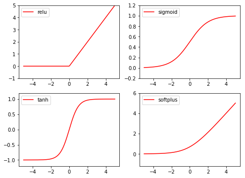

```python
plt.figure(1, figsize = (8, 6))
plt.subplot(221)
plt.plot(x_np, y_relu, c = 'red', label = 'relu')
plt.ylim((-1, 5))
plt.legend(loc = 'best')

plt.figure(1, figsize = (8, 6))
plt.subplot(222)
plt.plot(x_np, y_sigmoid, c = 'red', label = 'sigmoid')
plt.ylim((-0.2, 1.2))
plt.legend(loc = 'best')

plt.figure(1, figsize = (8, 6))
plt.subplot(223)
plt.plot(x_np, y_tanh, c = 'red', label = 'tanh')
plt.ylim((-1.2, 1.2))
plt.legend(loc = 'best')

plt.figure(1, figsize = (8, 6))
plt.subplot(224)
plt.plot(x_np, y_softplus, c = 'red', label = 'softplus')
plt.ylim((-1.2, 6))
plt.legend(loc = 'best')
```

## $\S3.\ Regression\ and\ Classification$

### $\S3.1\ Regression$

$\bigstar$ I have known what's regressions and classification.

```
torch.Size([100, 1])
```

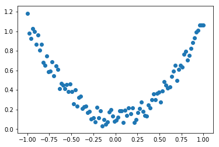

```python
import torch
import torch.nn.functional as F
import matplotlib.pyplot as plt

# torch can pnly deal with multi dim data???
## like [1, 2, 3, 4] not
## and [[1, 2, 3, 4]] okay
x = torch.unsqueeze(torch.linspace(-1, 1, 100), dim = 1)
print(x.size())
y = x.pow(2) + 0.2 * torch.rand(x.size())

x.requires_grad = True
y.requires_grad = True

plt.scatter(x.data.numpy(), y.data.numpy())
plt.show()
```

```python
class Net(torch.nn.Module):
    def _init_(self, n_feature, n_hidden, n_output):
        # must give this
        super(Net, self)._init_()
        self.hidden = torch.nn.Linear(n_feature, n_hidden)
        self.predict = torch.nn.Linear(n_hidden, n_output)

    def forward(self, x):# x is input data
        x = F.relu(self.hidden(x))
        x = self.predict(x)
        return x

net = Net(1, 10, 1)# 1 is input number, 10 neutron
print(net)
```

```
---------------------------------------------------------------------------
TypeError                                 Traceback (most recent call last)
<ipython-input-4-7dc40eba821e> in <module>
     11         return x
     12
---> 13 net = Net(1, 10, 1)# 1 is input number, 10 neutron
     14 print(net)

TypeError: __init__() takes 1 positional argument but 4 were given
```

```python
class Net(torch.nn.Module):
    def __init__(self, n_feature, n_hidden, n_output):
        super(Net, self).__init__()
        self.hidden = torch.nn.Linear(n_feature, n_hidden)   # hidden layer
        self.predict = torch.nn.Linear(n_hidden, n_output)   # output layer

    def forward(self, x):
        x = F.relu(self.hidden(x))      # activation function for hidden layer
        x = self.predict(x)             # linear output
        return x

net = Net(1, 10, 1)
```

**Kidding me??? __init__ but not _init_...**

```python
print(net)
```

```
Net(
  (hidden): Linear(in_features=1, out_features=10, bias=True)
  (predict): Linear(in_features=10, out_features=1, bias=True)
)
```

[output not shown]

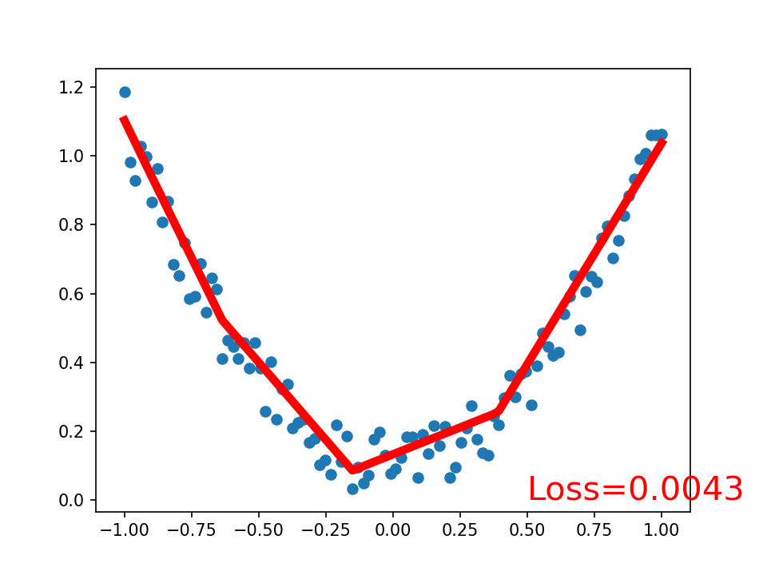

```python
%matplotlib notebook

# how to better nn? better parameters
optimizer = torch.optim.SGD(net.parameters(), lr=0.2)
loss_func = torch.nn.MSELoss()  # this is for regression mean squared loss

plt.ion()   # something about plotting
plt.show()

for t in range(200):
    prediction = net(x)     # input x and predict based on x

    loss = loss_func(prediction, y)     # must be (1. nn output, 2. target)

    optimizer.zero_grad()   # clear gradients for next train
    loss.backward()         # backpropagation, compute gradients
    optimizer.step()        # apply gradients

    if t % 5 == 0:
        # plot and show learning process
        plt.cla()
        plt.scatter(x.data.numpy(), y.data.numpy())
        plt.plot(x.data.numpy(), prediction.data.numpy(), 'r-', lw=5)
        plt.text(0.5, 0, 'Loss=%.4f' % loss.data.numpy(), fontdict={'size': 20, 'color':  'red'})
        plt.pause(0.1)

plt.ioff()
plt.show()
```

There seems sth wrong with the graph...

### $\S3.2\ Classification$

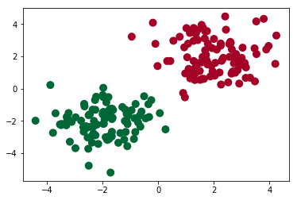

```python
import torch
import torch.nn.functional as F
import matplotlib.pyplot as plt

n_data = torch.ones(100, 2)
x0 = torch.normal(2 * n_data, 1)
y0 = torch.zeros(100)
x1 = torch.normal(-2 * n_data, 1)
y1 = torch.ones(100)
x = torch.cat((x0, x1), 0).type(torch.FloatTensor)
y = torch.cat((y0, y1), ).type(torch.LongTensor)

x.requires_grad = True
y.requires_grad = False

plt.scatter(x.data.numpy()[:, 0], x.data.numpy()[:, 1],
            c = y.data.numpy(), s = 100, lw = 0, cmap = 'RdYlGn')
plt.show()
```

```python
# construct nn
class Net(torch.nn.Module):
    def __init__(self, n_feature, n_hidden, n_output):
        super(Net, self).__init__()
        self.hidden = torch.nn.Linear(n_feature, n_hidden)
        self.predict = torch.nn.Linear(n_hidden, n_output)
    def forward(self, x):
        x = F.relu(self.hidden(x))
        x = self.predict(x)
        return x

net = Net(2, 10, 2)# input is the position of a point, 2-dim
print(net)
```

```
Net(
  (hidden): Linear(in_features=2, out_features=10, bias=True)
  (predict): Linear(in_features=10, out_features=2, bias=True)
)
```

[output not shown]

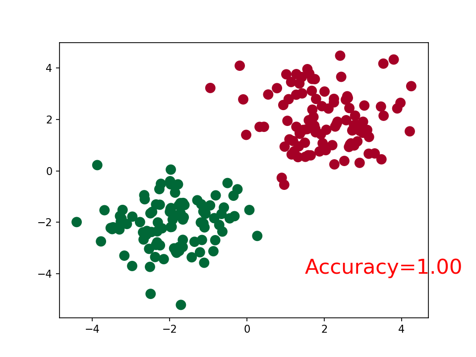

```python
%matplotlib notebook
plt.ion()
plt.show()

optimizer = torch.optim.SGD(net.parameters(), lr = 0.02)
loss_func = torch.nn.CrossEntropyLoss()

for t in range(100):
    prediction = net(x)

    loss = loss_func(prediction, y)

    optimizer.zero_grad()   # clear gradients for next train
    loss.backward()         # backpropagation, compute gradients
    optimizer.step()        # apply gradients

    if t % 2 == 0:
        # plot and show learning process
        plt.cla()
        prediction = torch.max(prediction, 1)[1]
        pred_y = prediction.data.numpy()
        target_y = y.data.numpy()
        plt.scatter(x.data.numpy()[:, 0], x.data.numpy()[:, 1], c=pred_y, s=100, lw=0, cmap='RdYlGn')
        accuracy = float((pred_y == target_y).astype(int).sum()) / float(target_y.size)
        plt.text(1.5, -4, 'Accuracy=%.2f' % accuracy, fontdict={'size': 20, 'color':  'red'})
        plt.pause(0.1)

plt.ioff()
plt.show()
```

NMD, bugs are too much. I have to use x as Float, y as Long, and set x as grad, y as no_grad. But I don't know why.

### $\S3.3\ Fast\ Construct$

```python
net2 = torch.nn.Sequential(torch.nn.Linear(2, 10),
                          torch.nn.ReLU(),
                          torch.nn.Linear(10, 2))
print(net2)
```

```
Sequential(
  (0): Linear(in_features=2, out_features=10, bias=True)
  (1): ReLU()
  (2): Linear(in_features=10, out_features=2, bias=True)
)
```

### $\S3.4\ Save\ It\ (2\ Ways)$

We surely can build nn quickly and save and restore (recover) it.

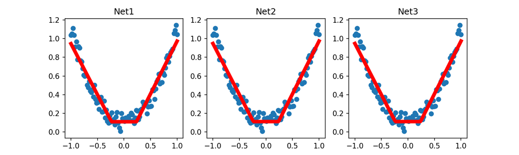

```python
# I copy and study from https://github.com/MorvanZhou/PyTorch-Tutorial/blob/master/tutorial-contents/304_save_reload.py
import torch
import matplotlib.pyplot as plt
%matplotlib notebook

# torch.manual_seed(1)    # reproducible

# fake data
x = torch.unsqueeze(torch.linspace(-1, 1, 100), dim=1)  # x data (tensor), shape=(100, 1)
y = x.pow(2) + 0.2*torch.rand(x.size())  # noisy y data (tensor), shape=(100, 1)

# The code below is deprecated in Pytorch 0.4. Now, autograd directly supports tensors
# x, y = Variable(x, requires_grad=False), Variable(y, requires_grad=False)


def save():
    # save net1
    net1 = torch.nn.Sequential(
        torch.nn.Linear(1, 10),
        torch.nn.ReLU(),
        torch.nn.Linear(10, 1)
    )
    optimizer = torch.optim.SGD(net1.parameters(), lr=0.5)
    loss_func = torch.nn.MSELoss()

    for t in range(100):
        prediction = net1(x)
        loss = loss_func(prediction, y)
        optimizer.zero_grad()
        loss.backward()
        optimizer.step()

    # plot result
    plt.figure(1, figsize=(10, 3))
    plt.subplot(131)
    plt.title('Net1')
    plt.scatter(x.data.numpy(), y.data.numpy())
    plt.plot(x.data.numpy(), prediction.data.numpy(), 'r-', lw=5)
    plt.show()

    # 2 ways to save the net
    torch.save(net1, 'net.pkl')  # save entire net
    torch.save(net1.state_dict(), 'net_params.pkl')   # save only the parameters


def restore_net():
    # restore entire net1 to net2
    net2 = torch.load('net.pkl')
    prediction = net2(x)

    # plot result
    plt.subplot(132)
    plt.title('Net2')
    plt.scatter(x.data.numpy(), y.data.numpy())
    plt.plot(x.data.numpy(), prediction.data.numpy(), 'r-', lw=5)
    plt.show()


def restore_params():
    # restore only the parameters in net1 to net3
    net3 = torch.nn.Sequential(
        torch.nn.Linear(1, 10),
        torch.nn.ReLU(),
        torch.nn.Linear(10, 1)
    )

    # copy net1's parameters into net3
    net3.load_state_dict(torch.load('net_params.pkl'))
    prediction = net3(x)

    # plot result
    plt.subplot(133)
    plt.title('Net3')
    plt.scatter(x.data.numpy(), y.data.numpy())
    plt.plot(x.data.numpy(), prediction.data.numpy(), 'r-', lw=5)
    plt.show()

# save net1
save()

# restore entire net (may slow)
restore_net()

# restore only the net parameters
restore_params()
```

- Fistly it doesn't show me any graph, then I add

  ```
  %matplotlib notebook
  ```

- Secondly it only shows me 3 straight lines but I wanna 3 trained ones, then I delete

  ```
  torch.manual_seed(1)    # reproducible
  ```

### $\S3.5\ Batch\ Training\ (批训练)$

This is batch training for big data to some extent.

```python
import torch
import torch.utils.data as Data# do mini batch training

# fake data
BATCH_SIZE = 5
x = torch.linspace(1, 15, 15)
y = torch.linspace(15, 1, 15)

# dataset
torch_dataset = Data.TensorDataset(x, y)
loader = Data.DataLoader(dataset = torch_dataset,
                        batch_size = BATCH_SIZE,
                        shuffle = True,
                        num_workers = 2)
```

```python
# training epoch times
for epoch in range(5):# 3 = 15 / 5, 所以每次训练（每个epoch），数据只能被分为三份
    for step, (batch_x, batch_y) in enumerate(loader):
        # training...
        print('Epoch: ', epoch, '| Step: ', step, '| batch x: ',
             batch_x.numpy(), '| batch y: ', batch_y.numpy())
```

```
Epoch:  0 | Step:  0 | batch x:  [ 5. 11.  1.  8. 12.] | batch y:  [11.  5. 15.  8.  4.]
Epoch:  0 | Step:  1 | batch x:  [ 3.  9. 10.  7.  6.] | batch y:  [13.  7.  6.  9. 10.]
Epoch:  0 | Step:  2 | batch x:  [ 4. 13. 14.  2. 15.] | batch y:  [12.  3.  2. 14.  1.]
Epoch:  1 | Step:  0 | batch x:  [14.  5.  2.  6. 11.] | batch y:  [ 2. 11. 14. 10.  5.]
Epoch:  1 | Step:  1 | batch x:  [ 8. 15.  1.  7.  4.] | batch y:  [ 8.  1. 15.  9. 12.]
Epoch:  1 | Step:  2 | batch x:  [ 9. 12. 10.  3. 13.] | batch y:  [ 7.  4.  6. 13.  3.]
Epoch:  2 | Step:  0 | batch x:  [13.  6. 12. 14.  8.] | batch y:  [ 3. 10.  4.  2.  8.]
Epoch:  2 | Step:  1 | batch x:  [ 3.  2. 15.  7.  1.] | batch y:  [13. 14.  1.  9. 15.]
Epoch:  2 | Step:  2 | batch x:  [10.  4. 11.  5.  9.] | batch y:  [ 6. 12.  5. 11.  7.]
Epoch:  3 | Step:  0 | batch x:  [14.  9.  6.  8. 13.] | batch y:  [ 2.  7. 10.  8.  3.]
Epoch:  3 | Step:  1 | batch x:  [ 1.  2. 10. 12. 11.] | batch y:  [15. 14.  6.  4.  5.]
Epoch:  3 | Step:  2 | batch x:  [ 4. 15.  3.  7.  5.] | batch y:  [12.  1. 13.  9. 11.]
Epoch:  4 | Step:  0 | batch x:  [ 2.  4.  9. 10. 15.] | batch y:  [14. 12.  7.  6.  1.]
Epoch:  4 | Step:  1 | batch x:  [13.  8.  7.  6. 14.] | batch y:  [ 3.  8.  9. 10.  2.]
Epoch:  4 | Step:  2 | batch x:  [ 3. 12.  5.  1. 11.] | batch y:  [13.  4. 11. 15.  5.]
```

### $\S3.6\ Optimizer\ (优化器可加速网络的训练)$

$\bigstar$ To accelerate, we may need to split data and then put them into NN, like SGD method.

$\bigstar$ It indeed optimize our parameters

- Momentum
- AdaGrad
- RMSProp
- Adam

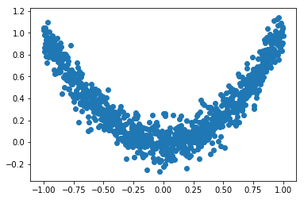

```
0
1
2
3
4
5
6
7
8
9
10
11
```

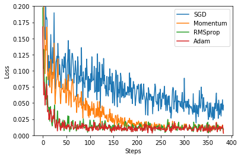

```python
import torch
import torch.utils.data as Data
import torch.nn.functional as F
import matplotlib.pyplot as plt
%matplotlib inline

# 超参数 hyper parameters
LR = 0.01
BATCH_SIZE = 32
EPOCH = 12

# fake data
x = torch.unsqueeze(torch.linspace(-1, 1, 1000), dim = 1)
y = x.pow(2) + 0.1 * torch.normal(torch.zeros(*x.size()))

# plot dataset
plt.scatter(x.numpy(), y.numpy())
plt.show()

#################################
# 先看torch.squeeze() 这个函数主要对数据的维度进行压缩，去掉维数为1的的维度，比如是一行或者一列这种，
# 一个一行三列（1,3）的数去掉第一个维数为一的维度之后就变成（3）行。squeeze(a)就是将a中所有为1的维度删掉。
# 不为1的维度没有影响。a.squeeze(N) 就是去掉a中指定的维数为一的维度。
# 还有一种形式就是b=torch.squeeze(a，N) a中去掉指定的定的维数为一的维度。
# 再看torch.unsqueeze()这个函数主要是对数据维度进行扩充。
# 给指定位置加上维数为一的维度，比如原本有个三行的数据（3），
# 在0的位置加了一维就变成一行三列（1,3）。
# a.squeeze(N) 就是在a中指定位置N加上一个维数为1的维度。
# 还有一种形式就是b=torch.squeeze(a，N) a就是在a中指定位置N加上一个维数为1的维度
# https://blog.csdn.net/xiexu911/article/details/80820028
##################################

torch_dataset = Data.TensorDataset(x, y)
loader = Data.DataLoader(torch_dataset, BATCH_SIZE, shuffle = True)

class Net(torch.nn.Module):
    def __init__(self):
        super(Net, self).__init__()
        self.hidden = torch.nn.Linear(1, 20)
        self.predict = torch.nn.Linear(20, 1)
    def forward(self, x):
        x = F.relu(self.hidden(x))
        x = self.predict(x)
        return x

# nets
net_SGD = Net()
net_Momentum = Net()
net_RMSProp = Net()
net_Adam = Net()

nets = [net_SGD, net_Momentum, net_RMSProp, net_Adam]

# different optimizers
opt_SGD = torch.optim.SGD(net_SGD.parameters(), lr = LR)
opt_Momentum = torch.optim.SGD(net_Momentum.parameters(), lr = LR, momentum = 0.8)
opt_RMSProp = torch.optim.RMSprop(net_RMSProp.parameters(), lr = LR, alpha = 0.9)
opt_Adam = torch.optim.Adam(net_Adam.parameters(), lr = LR, betas = (0.9, 0.99))
optimizers = [opt_SGD, opt_Momentum, opt_RMSProp, opt_Adam]

loss_func = torch.nn.MSELoss()
losses_his = [[], [], [], []]   # record loss

# training
for epoch in range(EPOCH):
    print(epoch)
    for step, (b_x, b_y) in enumerate(loader):          # for each training step
        for net, opt, l_his in zip(nets, optimizers, losses_his):
            output = net(b_x)              # get output for every net
            loss = loss_func(output, b_y)  # compute loss for every net
            opt.zero_grad()                # clear gradients for next train
            loss.backward()                # backpropagation, compute gradients
            opt.step()                     # apply gradients
            l_his.append(loss.data.numpy())     # loss recoder

labels = ['SGD', 'Momentum', 'RMSprop', 'Adam']
for i, l_his in enumerate(losses_his):
    plt.plot(l_his, label=labels[i])
plt.legend(loc='best')
plt.xlabel('Steps')
plt.ylabel('Loss')
plt.ylim((0, 0.2))
plt.show()
```

## $\S4.\ 卷积神经网络\ Convolutional\ Neural\ Network$

CNN.

卷积指处理一片区域的图像。

### $\S4.1\ CNN卷积神经网络$

Agenda：

- MNIST
- CNN
- Training

```
Downloading http://yann.lecun.com/exdb/mnist/train-images-idx3-ubyte.gz to ./mnist/MNIST\raw\train-images-idx3-ubyte.gz
```

[output not shown]

```
Extracting ./mnist/MNIST\raw\train-images-idx3-ubyte.gz
```

[output not shown]

```
Downloading http://yann.lecun.com/exdb/mnist/train-labels-idx1-ubyte.gz to ./mnist/MNIST\raw\train-labels-idx1-ubyte.gz
Extracting ./mnist/MNIST\raw\train-labels-idx1-ubyte.gz
```

[output not shown]

```
Downloading http://yann.lecun.com/exdb/mnist/t10k-images-idx3-ubyte.gz to ./mnist/MNIST\raw\t10k-images-idx3-ubyte.gz
```

[output not shown]

```
Extracting ./mnist/MNIST\raw\t10k-images-idx3-ubyte.gz
Downloading http://yann.lecun.com/exdb/mnist/t10k-labels-idx1-ubyte.gz to ./mnist/MNIST\raw\t10k-labels-idx1-ubyte.gz
```

[output not shown]

```
Extracting ./mnist/MNIST\raw\t10k-labels-idx1-ubyte.gz
Processing...
Done!
torch.Size([60000, 28, 28])
torch.Size([60000])
```

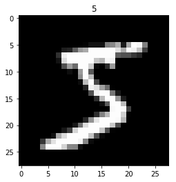

```python
# https://github.com/MorvanZhou/PyTorch-Tutorial/blob/master/tutorial-contents/401_CNN.py
import torch
import torch.nn as nn
import torch.utils.data as Data
import torchvision
import matplotlib.pyplot as plt
import os

# torch.manual_seed(1)    # reproducible

# Hyper Parameters
EPOCH = 1               # train the training data n times, to save time, we just train 1 epoch
BATCH_SIZE = 50
LR = 0.001              # learning rate
DOWNLOAD_MNIST = False


# Mnist digits dataset
if not(os.path.exists('./mnist/')) or not os.listdir('./mnist/'):
    # not mnist dir or mnist is empyt dir
    DOWNLOAD_MNIST = True

train_data = torchvision.datasets.MNIST(
    root='./mnist/',
    train=True,                                     # this is training data
    transform=torchvision.transforms.ToTensor(),    # Converts a PIL.Image or numpy.ndarray to
                                                    # torch.FloatTensor of shape (C x H x W) and normalize in the range [0.0, 1.0]
    download=DOWNLOAD_MNIST,
)

# plot one example
print(train_data.train_data.size())                 # (60000, 28, 28)
print(train_data.train_labels.size())               # (60000)
plt.imshow(train_data.train_data[0].numpy(), cmap='gray')
plt.title('%i' % train_data.train_labels[0])
plt.show()
```

```python
# Data Loader for easy mini-batch return in training, the image batch shape will be (50, 1, 28, 28)
train_loader = Data.DataLoader(dataset=train_data, batch_size=BATCH_SIZE, shuffle=True, num_workers = 2)

# pick 2000 samples to speed up testing
test_data = torchvision.datasets.MNIST(root='./mnist/', train=False)
test_x = torch.unsqueeze(test_data.test_data, dim=1).type(torch.FloatTensor)[:2000]/255.   # shape from (2000, 28, 28) to (2000, 1, 28, 28), value in range(0,1)
test_y = test_data.test_labels[:2000]


class CNN(nn.Module):
    def __init__(self):
        super(CNN, self).__init__()
        self.conv1 = nn.Sequential(         # input shape (1, 28, 28)
            nn.Conv2d(
                in_channels=1,              # input height
                out_channels=16,            # n_filters 16个同时扫描，提取16个特征
                kernel_size=5,              # filter size
                stride=1,                   # filter movement/step
                padding=2,                  # if want same width and length of this image after Conv2d, padding=(kernel_size-1)/2 if stride=1
            ),                              # output shape (16, 28, 28)
            nn.ReLU(),                      # activation
            nn.MaxPool2d(kernel_size=2),    # choose max value in 2x2 area, output shape (16, 14, 14)
        )# 16, 28, 28
        self.conv2 = nn.Sequential(         # input shape (16, 14, 14)
            nn.Conv2d(16, 32, 5, 1, 2),     # output shape (32, 14, 14)
            nn.ReLU(),                      # activation
            nn.MaxPool2d(2),                # output shape (32, 7, 7)
        )# 16, 14, 14
        self.out = nn.Linear(32 * 7 * 7, 10)   # fully connected layer, output 10 classes

    def forward(self, x):
        x = self.conv1(x)
        x = self.conv2(x)
        x = x.view(x.size(0), -1)           # flatten the output of conv2 to (batch_size, 32 * 7 * 7)
        output = self.out(x)
        return output, x    # return x for visualization


cnn = CNN()
print(cnn)  # net architecture
```

```
CNN(
  (conv1): Sequential(
    (0): Conv2d(1, 16, kernel_size=(5, 5), stride=(1, 1), padding=(2, 2))
    (1): ReLU()
    (2): MaxPool2d(kernel_size=2, stride=2, padding=0, dilation=1, ceil_mode=False)
  )
  (conv2): Sequential(
    (0): Conv2d(16, 32, kernel_size=(5, 5), stride=(1, 1), padding=(2, 2))
    (1): ReLU()
    (2): MaxPool2d(kernel_size=2, stride=2, padding=0, dilation=1, ceil_mode=False)
  )
  (out): Linear(in_features=1568, out_features=10, bias=True)
)
```

```
Epoch:  0 | train loss: 2.3151 | test accuracy: 0.12
```

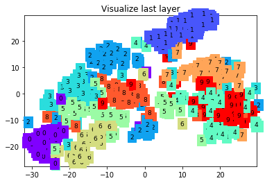

```
Epoch:  0 | train loss: 0.3620 | test accuracy: 0.84
```

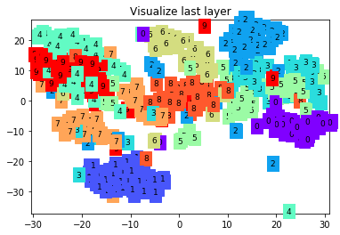

```
Epoch:  0 | train loss: 0.3756 | test accuracy: 0.89
```

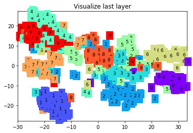

```
Epoch:  0 | train loss: 0.1736 | test accuracy: 0.92
```

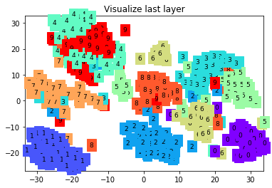

```
Epoch:  0 | train loss: 0.1612 | test accuracy: 0.94
```

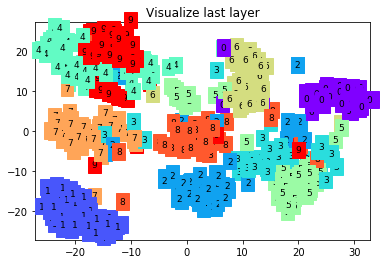

```
Epoch:  0 | train loss: 0.1590 | test accuracy: 0.94
```

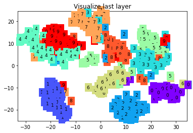

```
Epoch:  0 | train loss: 0.1308 | test accuracy: 0.95
```

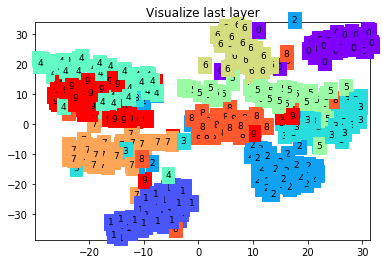

```
Epoch:  0 | train loss: 0.2281 | test accuracy: 0.96
```

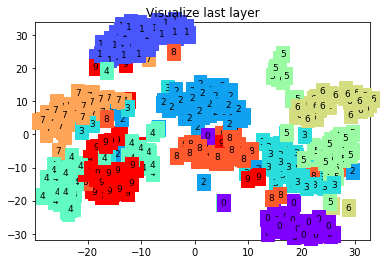

```
Epoch:  0 | train loss: 0.0381 | test accuracy: 0.97
```

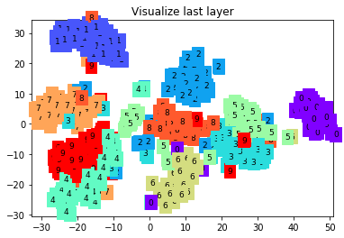

```
Epoch:  0 | train loss: 0.1145 | test accuracy: 0.96
```

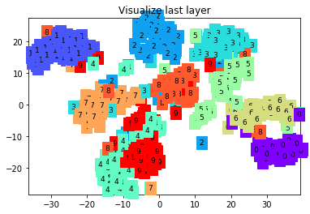

```
Epoch:  0 | train loss: 0.0338 | test accuracy: 0.95
```

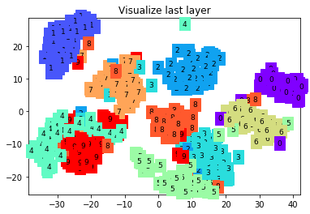

```
Epoch:  0 | train loss: 0.0423 | test accuracy: 0.97
```

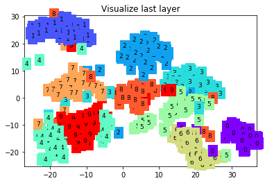

```
Epoch:  0 | train loss: 0.0662 | test accuracy: 0.97
```

[12 more figures not shown]

```
[7 2 1 0 4 1 4 9 5 9] prediction number
[7 2 1 0 4 1 4 9 5 9] real number
```

```python
optimizer = torch.optim.Adam(cnn.parameters(), lr=LR)   # optimize all cnn parameters
loss_func = nn.CrossEntropyLoss()                       # the target label is not one-hotted

# following function (plot_with_labels) is for visualization, can be ignored if not interested
from matplotlib import cm
try: from sklearn.manifold import TSNE; HAS_SK = True
except: HAS_SK = False; print('Please install sklearn for layer visualization')
def plot_with_labels(lowDWeights, labels):
    plt.cla()
    X, Y = lowDWeights[:, 0], lowDWeights[:, 1]
    for x, y, s in zip(X, Y, labels):
        c = cm.rainbow(int(255 * s / 9)); plt.text(x, y, s, backgroundcolor=c, fontsize=9)
    plt.xlim(X.min(), X.max()); plt.ylim(Y.min(), Y.max()); plt.title('Visualize last layer'); plt.show(); plt.pause(0.01)

plt.ion()
# training and testing
for epoch in range(EPOCH):
    for step, (b_x, b_y) in enumerate(train_loader):   # gives batch data, normalize x when iterate train_loader

        output = cnn(b_x)[0]               # cnn output
        loss = loss_func(output, b_y)   # cross entropy loss
        optimizer.zero_grad()           # clear gradients for this training step
        loss.backward()                 # backpropagation, compute gradients
        optimizer.step()                # apply gradients

        if step % 50 == 0:
            test_output, last_layer = cnn(test_x)
            pred_y = torch.max(test_output, 1)[1].data.numpy()
            accuracy = float((pred_y == test_y.data.numpy()).astype(int).sum()) / float(test_y.size(0))
            print('Epoch: ', epoch, '| train loss: %.4f' % loss.data.numpy(), '| test accuracy: %.2f' % accuracy)
            if HAS_SK:
                # Visualization of trained flatten layer (T-SNE)
                tsne = TSNE(perplexity=30, n_components=2, init='pca', n_iter=5000)
                plot_only = 500
                low_dim_embs = tsne.fit_transform(last_layer.data.numpy()[:plot_only, :])
                labels = test_y.numpy()[:plot_only]
                plot_with_labels(low_dim_embs, labels)
plt.ioff()

# print 10 predictions from test data
test_output, _ = cnn(test_x[:10])
pred_y = torch.max(test_output, 1)[1].data.numpy()
print(pred_y, 'prediction number')
print(test_y[:10].numpy(), 'real number')
```

### $\S4.2\ RNN循环神经神经网络$

$\bigstar$ 注意到 LSTM，long-short-term-memory，好像是一种RNN的序列嵌套，就是这个意思。

```
torch.Size([60000, 28, 28])
torch.Size([60000])
```

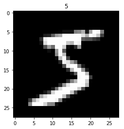

```
RNN(
  (rnn): LSTM(28, 64, batch_first=True)
  (out): Linear(in_features=64, out_features=10, bias=True)
)
```

```python
import torch
from torch import nn
import torchvision.datasets as dsets
import torchvision.transforms as transforms
import matplotlib.pyplot as plt


# torch.manual_seed(1)    # reproducible

# Hyper Parameters
EPOCH = 1               # train the training data n times, to save time, we just train 1 epoch
BATCH_SIZE = 64         # 每28步中的一步读取28*28图片的一行信息，一行信息包括了28个像素点
TIME_STEP = 28          # rnn time step / image height
INPUT_SIZE = 28         # rnn input size / image width
LR = 0.01               # learning rate
DOWNLOAD_MNIST = True   # set to True if haven't download the data


# Mnist digital dataset
train_data = dsets.MNIST(
    root='./mnist/',
    train=True,                         # this is training data
    transform=transforms.ToTensor(),    # Converts a PIL.Image or numpy.ndarray to
                                        # torch.FloatTensor of shape (C x H x W) and normalize in the range [0.0, 1.0]
    download=DOWNLOAD_MNIST,            # download it if you don't have it
)

# plot one example
print(train_data.train_data.size())     # (60000, 28, 28)
print(train_data.train_labels.size())   # (60000)
plt.imshow(train_data.train_data[0].numpy(), cmap='gray')
plt.title('%i' % train_data.train_labels[0])
plt.show()

# Data Loader for easy mini-batch return in training
train_loader = torch.utils.data.DataLoader(dataset=train_data, batch_size=BATCH_SIZE, shuffle=True)

# convert test data into Variable, pick 2000 samples to speed up testing
test_data = dsets.MNIST(root='./mnist/', train=False, transform=transforms.ToTensor())
test_x = test_data.test_data.type(torch.FloatTensor)[:2000]/255.   # shape (2000, 28, 28) value in range(0,1)
test_y = test_data.test_labels.numpy()[:2000]    # covert to numpy array


class RNN(nn.Module):
    def __init__(self):
        super(RNN, self).__init__()

        self.rnn = nn.LSTM(         # if use nn.RNN(), it hardly learns
            input_size=INPUT_SIZE,
            hidden_size=64,         # rnn hidden unit
            num_layers=1,           # number of rnn layer
            batch_first=True,       # input & output will has batch size as 1s dimension. e.g. (batch, time_step, input_size)
        )

        self.out = nn.Linear(64, 10)

    def forward(self, x):
        # x shape (batch, time_step, input_size)
        # r_out shape (batch, time_step, output_size)
        # h_n shape (n_layers, batch, hidden_size)
        # h_c shape (n_layers, batch, hidden_size)
        r_out, (h_n, h_c) = self.rnn(x, None)   # None represents zero initial hidden state

        # choose r_out at the last time step
        out = self.out(r_out[:, -1, :])
        return out


rnn = RNN()
print(rnn)
```

```python
optimizer = torch.optim.Adam(rnn.parameters(), lr=LR)   # optimize all cnn parameters
loss_func = nn.CrossEntropyLoss()                       # the target label is not one-hotted

# training and testing
for epoch in range(EPOCH):
    for step, (b_x, b_y) in enumerate(train_loader):        # gives batch data
        b_x = b_x.view(-1, 28, 28)              # reshape x to (batch, time_step, input_size)

        output = rnn(b_x)                               # rnn output
        loss = loss_func(output, b_y)                   # cross entropy loss
        optimizer.zero_grad()                           # clear gradients for this training step
        loss.backward()                                 # backpropagation, compute gradients
        optimizer.step()                                # apply gradients

        if step % 50 == 0:
            test_output = rnn(test_x)                   # (samples, time_step, input_size)
            pred_y = torch.max(test_output, 1)[1].data.numpy()
            accuracy = float((pred_y == test_y).astype(int).sum()) / float(test_y.size)
            print('Epoch: ', epoch, '| train loss: %.4f' % loss.data.numpy(), '| test accuracy: %.2f' % accuracy)

# print 10 predictions from test data
test_output = rnn(test_x[:10].view(-1, 28, 28))
pred_y = torch.max(test_output, 1)[1].data.numpy()
print(pred_y, 'prediction number')
print(test_y[:10], 'real number')
```

```
Epoch:  0 | train loss: 2.3067 | test accuracy: 0.12
Epoch:  0 | train loss: 0.8803 | test accuracy: 0.62
Epoch:  0 | train loss: 1.2020 | test accuracy: 0.73
Epoch:  0 | train loss: 0.4650 | test accuracy: 0.82
Epoch:  0 | train loss: 0.5025 | test accuracy: 0.87
Epoch:  0 | train loss: 0.1268 | test accuracy: 0.88
Epoch:  0 | train loss: 0.1679 | test accuracy: 0.93
Epoch:  0 | train loss: 0.1948 | test accuracy: 0.92
Epoch:  0 | train loss: 0.0261 | test accuracy: 0.92
Epoch:  0 | train loss: 0.1574 | test accuracy: 0.93
Epoch:  0 | train loss: 0.4096 | test accuracy: 0.93
Epoch:  0 | train loss: 0.2217 | test accuracy: 0.94
Epoch:  0 | train loss: 0.3194 | test accuracy: 0.95
Epoch:  0 | train loss: 0.1775 | test accuracy: 0.94
Epoch:  0 | train loss: 0.1389 | test accuracy: 0.95
Epoch:  0 | train loss: 0.2513 | test accuracy: 0.95
Epoch:  0 | train loss: 0.0555 | test accuracy: 0.96
Epoch:  0 | train loss: 0.0949 | test accuracy: 0.94
Epoch:  0 | train loss: 0.2774 | test accuracy: 0.96
[7 2 1 0 4 1 4 9 5 9] prediction number
[7 2 1 0 4 1 4 9 5 9] real number
```

### $\S4.3\ RNN循环神经神经网络（This\ time\ is\ regression\ but\ not\ classification）$

$\bigstar$ 每个state输出一下比较真实数据。

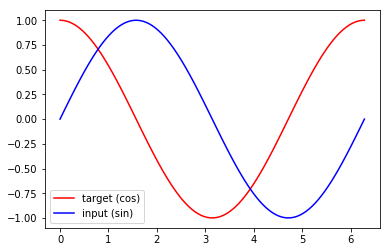

```python
import torch
from torch import nn
import numpy as np
import matplotlib.pyplot as plt

# torch.manual_seed(1)    # reproducible

# Hyper Parameters
TIME_STEP = 10      # rnn time step
INPUT_SIZE = 1      # rnn input size
LR = 0.02           # learning rate

# show data
steps = np.linspace(0, np.pi*2, 100, dtype=np.float32)  # float32 for converting torch FloatTensor
x_np = np.sin(steps)
y_np = np.cos(steps)
plt.plot(steps, y_np, 'r-', label='target (cos)')
plt.plot(steps, x_np, 'b-', label='input (sin)')
plt.legend(loc='best')
plt.show()
```

```
RNN(
  (rnn): RNN(1, 32, batch_first=True)
  (out): Linear(in_features=32, out_features=1, bias=True)
)
```

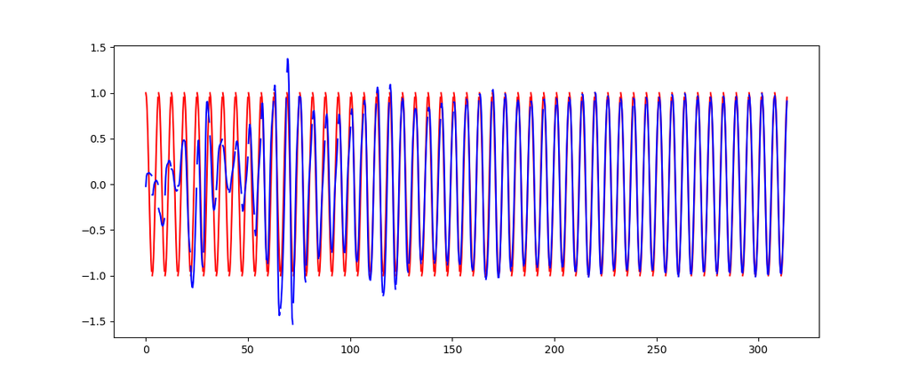

```python
%matplotlib notebook
class RNN(nn.Module):
    def __init__(self):
        super(RNN, self).__init__()

        self.rnn = nn.RNN(      # this time use simple RNN
            input_size=INPUT_SIZE,
            hidden_size=32,     # rnn hidden unit
            num_layers=1,       # number of rnn layer
            batch_first=True,   # input & output will has batch size as 1s dimension. e.g. (batch, time_step, input_size)
        )
        self.out = nn.Linear(32, 1)

    def forward(self, x, h_state):
        # x (batch, time_step, input_size)
        # h_state (n_layers, batch, hidden_size)
        # r_out (batch, time_step, hidden_size)
        r_out, h_state = self.rnn(x, h_state)

        outs = []    # save all predictions
        for time_step in range(r_out.size(1)):    # calculate output for each time step
            outs.append(self.out(r_out[:, time_step, :]))
        return torch.stack(outs, dim=1), h_state

        # instead, for simplicity, you can replace above codes by follows
        # r_out = r_out.view(-1, 32)
        # outs = self.out(r_out)
        # outs = outs.view(-1, TIME_STEP, 1)
        # return outs, h_state

        # or even simpler, since nn.Linear can accept inputs of any dimension
        # and returns outputs with same dimension except for the last
        # outs = self.out(r_out)
        # return outs

rnn = RNN()
print(rnn)

optimizer = torch.optim.Adam(rnn.parameters(), lr=LR)   # optimize all cnn parameters
loss_func = nn.MSELoss()

h_state = None      # for initial hidden state

plt.figure(1, figsize=(12, 5))
plt.ion()           # continuously plot

for step in range(100):
    start, end = step * np.pi, (step+1)*np.pi   # time range
    # use sin predicts cos
    steps = np.linspace(start, end, TIME_STEP, dtype=np.float32, endpoint=False)  # float32 for converting torch FloatTensor
    x_np = np.sin(steps)
    y_np = np.cos(steps)

    x = torch.from_numpy(x_np[np.newaxis, :, np.newaxis])    # shape (batch, time_step, input_size)
    y = torch.from_numpy(y_np[np.newaxis, :, np.newaxis])

    prediction, h_state = rnn(x, h_state)   # rnn output
    # !! next step is important !!
    h_state = h_state.data        # repack the hidden state, break the connection from last iteration

    loss = loss_func(prediction, y)         # calculate loss
    optimizer.zero_grad()                   # clear gradients for this training step
    loss.backward()                         # backpropagation, compute gradients
    optimizer.step()                        # apply gradients

    # plotting
    plt.plot(steps, y_np.flatten(), 'r-')
    plt.plot(steps, prediction.data.numpy().flatten(), 'b-')
    plt.draw(); plt.pause(0.05)

plt.ioff()
plt.show()
```

### $\S4.4 \ AutoEncoder（自编码器）$

相当于一个压缩图片后解压的前半过程。这个过程在视频中有张形象的图片作为解释，这里不导入图片了。

这是非监督学习的一种，在训练的过程中其实只用了输入数据，并且学到的精髓可以看作是一种降维。与PCA相比，自编码器往往更强。

```
torch.Size([60000, 28, 28])
torch.Size([60000])
```

[output not shown]

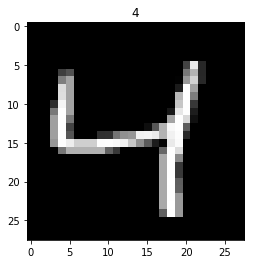

```python
import torch
import torch.nn as nn
import torch.utils.data as Data
import torchvision
import matplotlib.pyplot as plt
from mpl_toolkits.mplot3d import Axes3D
from matplotlib import cm
import numpy as np
%matplotlib inline

# torch.manual_seed(1)    # reproducible

# Hyper Parameters
EPOCH = 10
BATCH_SIZE = 64
LR = 0.005         # learning rate
DOWNLOAD_MNIST = False
N_TEST_IMG = 5

# Mnist digits dataset
train_data = torchvision.datasets.MNIST(
    root='./mnist/',
    train=True,                                     # this is training data
    transform=torchvision.transforms.ToTensor(),    # Converts a PIL.Image or numpy.ndarray to
                                                    # torch.FloatTensor of shape (C x H x W) and normalize in the range [0.0, 1.0]
    download=DOWNLOAD_MNIST,                        # download it if you don't have it
)

# plot one example
print(train_data.train_data.size())     # (60000, 28, 28)
print(train_data.train_labels.size())   # (60000)
plt.imshow(train_data.train_data[2].numpy(), cmap='gray')
plt.title('%i' % train_data.train_labels[2])
plt.show()
```

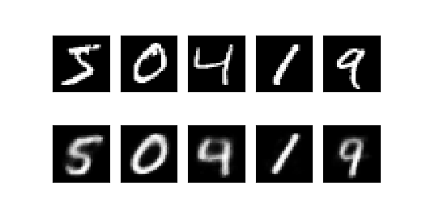

```
Epoch:  0 | train loss: 0.2330
Epoch:  0 | train loss: 0.0660
Epoch:  0 | train loss: 0.0633
Epoch:  0 | train loss: 0.0603
Epoch:  0 | train loss: 0.0569
Epoch:  0 | train loss: 0.0524
Epoch:  0 | train loss: 0.0487
Epoch:  0 | train loss: 0.0463
Epoch:  0 | train loss: 0.0506
Epoch:  0 | train loss: 0.0497
Epoch:  1 | train loss: 0.0440
Epoch:  1 | train loss: 0.0450
Epoch:  1 | train loss: 0.0490
Epoch:  1 | train loss: 0.0403
Epoch:  1 | train loss: 0.0462
Epoch:  1 | train loss: 0.0457
Epoch:  1 | train loss: 0.0397
Epoch:  1 | train loss: 0.0430
Epoch:  1 | train loss: 0.0474
Epoch:  1 | train loss: 0.0417
Epoch:  2 | train loss: 0.0399
Epoch:  2 | train loss: 0.0412
Epoch:  2 | train loss: 0.0394
Epoch:  2 | train loss: 0.0410
Epoch:  2 | train loss: 0.0373
Epoch:  2 | train loss: 0.0402
Epoch:  2 | train loss: 0.0390
Epoch:  2 | train loss: 0.0420
Epoch:  2 | train loss: 0.0399
Epoch:  2 | train loss: 0.0415
Epoch:  3 | train loss: 0.0367
Epoch:  3 | train loss: 0.0356
Epoch:  3 | train loss: 0.0371
Epoch:  3 | train loss: 0.0448
Epoch:  3 | train loss: 0.0435
Epoch:  3 | train loss: 0.0358
Epoch:  3 | train loss: 0.0398
Epoch:  3 | train loss: 0.0336
Epoch:  3 | train loss: 0.0357
Epoch:  3 | train loss: 0.0391
```

[output cut: 45 more lines]

```
Epoch:  8 | train loss: 0.0330
Epoch:  8 | train loss: 0.0348
Epoch:  8 | train loss: 0.0323
Epoch:  8 | train loss: 0.0373
Epoch:  8 | train loss: 0.0380
Epoch:  9 | train loss: 0.0369
Epoch:  9 | train loss: 0.0360
Epoch:  9 | train loss: 0.0335
Epoch:  9 | train loss: 0.0336
Epoch:  9 | train loss: 0.0369
Epoch:  9 | train loss: 0.0322
Epoch:  9 | train loss: 0.0346
Epoch:  9 | train loss: 0.0341
Epoch:  9 | train loss: 0.0348
Epoch:  9 | train loss: 0.0351
```

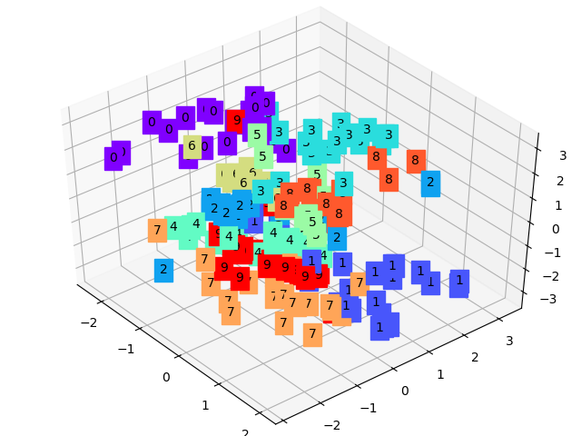

```python
# Data Loader for easy mini-batch return in training, the image batch shape will be (50, 1, 28, 28)
train_loader = Data.DataLoader(dataset=train_data, batch_size=BATCH_SIZE, shuffle=True)

%matplotlib notebook

class AutoEncoder(nn.Module):
    def __init__(self):
        super(AutoEncoder, self).__init__()

        self.encoder = nn.Sequential(
            nn.Linear(28*28, 128),
            nn.Tanh(),
            nn.Linear(128, 64),
            nn.Tanh(),
            nn.Linear(64, 12),
            nn.Tanh(),
            nn.Linear(12, 3),   # compress to 3 features which can be visualized in plt
        )
        self.decoder = nn.Sequential(
            nn.Linear(3, 12),
            nn.Tanh(),
            nn.Linear(12, 64),
            nn.Tanh(),
            nn.Linear(64, 128),
            nn.Tanh(),
            nn.Linear(128, 28*28),
            nn.Sigmoid(),       # compress to a range (0, 1)
        )

    def forward(self, x):
        encoded = self.encoder(x)
        decoded = self.decoder(encoded)
        return encoded, decoded


autoencoder = AutoEncoder()

optimizer = torch.optim.Adam(autoencoder.parameters(), lr=LR)
loss_func = nn.MSELoss()

# initialize figure
f, a = plt.subplots(2, N_TEST_IMG, figsize=(5, 2))
plt.ion()   # continuously plot

# original data (first row) for viewing
view_data = train_data.train_data[:N_TEST_IMG].view(-1, 28*28).type(torch.FloatTensor)/255.
for i in range(N_TEST_IMG):
    a[0][i].imshow(np.reshape(view_data.data.numpy()[i], (28, 28)), cmap='gray'); a[0][i].set_xticks(()); a[0][i].set_yticks(())

for epoch in range(EPOCH):
    for step, (x, b_label) in enumerate(train_loader):
        b_x = x.view(-1, 28*28)   # batch x, shape (batch, 28*28)
        b_y = x.view(-1, 28*28)   # batch y, shape (batch, 28*28)

        encoded, decoded = autoencoder(b_x)

        loss = loss_func(decoded, b_y)      # mean square error
        optimizer.zero_grad()               # clear gradients for this training step
        loss.backward()                     # backpropagation, compute gradients
        optimizer.step()                    # apply gradients

        if step % 100 == 0:
            print('Epoch: ', epoch, '| train loss: %.4f' % loss.data.numpy())

            # plotting decoded image (second row)
            _, decoded_data = autoencoder(view_data)
            for i in range(N_TEST_IMG):
                a[1][i].clear()
                a[1][i].imshow(np.reshape(decoded_data.data.numpy()[i], (28, 28)), cmap='gray')
                a[1][i].set_xticks(()); a[1][i].set_yticks(())
            plt.draw(); plt.pause(0.05)

plt.ioff()
plt.show()

# visualize in 3D plot
view_data = train_data.train_data[:200].view(-1, 28*28).type(torch.FloatTensor)/255.
encoded_data, _ = autoencoder(view_data)
fig = plt.figure(2); ax = Axes3D(fig)
X, Y, Z = encoded_data.data[:, 0].numpy(), encoded_data.data[:, 1].numpy(), encoded_data.data[:, 2].numpy()
values = train_data.train_labels[:200].numpy()
for x, y, z, s in zip(X, Y, Z, values):
    c = cm.rainbow(int(255*s/9)); ax.text(x, y, z, s, backgroundcolor=c)
ax.set_xlim(X.min(), X.max()); ax.set_ylim(Y.min(), Y.max()); ax.set_zlim(Z.min(), Z.max())
plt.show()
```

### $\S4.5 \ DNQ\ (Deep\ Q\ Network)$

电竞武器喵喵喵？！

融合Q learning 和 deep。

有点小懵，的确没学懂。

强化学习，不经过监督，还记得一点。

```python
import torch
import torch.nn as nn
import torch.nn.functional as F
import numpy as np
import gym

# Hyper Parameters
BATCH_SIZE = 32
LR = 0.01                   # learning rate
EPSILON = 0.9               # greedy policy
GAMMA = 0.9                 # reward discount
TARGET_REPLACE_ITER = 100   # target update frequency
# simulation site by gym, to set up a pole
MEMORY_CAPACITY = 2000
env = gym.make('CartPole-v0')
env = env.unwrapped
N_ACTIONS = env.action_space.n
N_STATES = env.observation_space.shape[0]
ENV_A_SHAPE = 0 if isinstance(env.action_space.sample(), int) else env.action_space.sample().shape     # to confirm the shape
```

```python
# 建立两个network? 是的。
class Net(nn.Module):
    def __init__(self, ):
        # clarify your info!
        super(Net, self).__init__()
        self.fc1 = nn.Linear(N_STATES, 50)
        self.fc1.weight.data.normal_(0, 0.1)   # initialization
        self.out = nn.Linear(50, N_ACTIONS)
        self.out.weight.data.normal_(0, 0.1)   # initialization

    def forward(self, x):
        x = self.fc1(x)
        x = F.relu(x)
        actions_value = self.out(x)            # x is action
        return actions_value


class DQN(object):
    def __init__(self):
        # eval_net, self.target_net 参数不同，把eval的参数时不时转换到target上，使之有一个延迟的更新效果
        self.eval_net, self.target_net = Net(), Net()

        self.learn_step_counter = 0                                     # for target updating
        self.memory_counter = 0                                         # for storing memory
        self.memory = np.zeros((MEMORY_CAPACITY, N_STATES * 2 + 2))     # initialize memory s, a, r, s_ 两个state和action和reward
        self.optimizer = torch.optim.Adam(self.eval_net.parameters(), lr=LR)
        self.loss_func = nn.MSELoss()

    def choose_action(self, x):
        x = torch.unsqueeze(torch.FloatTensor(x), 0) # x是观测值
        # input only one sample
        if np.random.uniform() < EPSILON:   # greedy， EPSILON是选择动作的概率，greedy指哪个动作的价值高就选哪个
            actions_value = self.eval_net.forward(x)
            action = torch.max(actions_value, 1)[1].data.numpy()
            action = action[0] if ENV_A_SHAPE == 0 else action.reshape(ENV_A_SHAPE)  # return the argmax index
        else:   # random
            action = np.random.randint(0, N_ACTIONS)
            action = action if ENV_A_SHAPE == 0 else action.reshape(ENV_A_SHAPE)
        return action

    def store_transition(self, s, a, r, s_):
        transition = np.hstack((s, [a, r], s_))# 捆在一起
        # replace the old memory with new memory
        index = self.memory_counter % MEMORY_CAPACITY
        self.memory[index, :] = transition
        self.memory_counter += 1

    def learn(self):
        # target parameter update
        if self.learn_step_counter % TARGET_REPLACE_ITER == 0:
            self.target_net.load_state_dict(self.eval_net.state_dict())
        self.learn_step_counter += 1

        # sample batch transitions
        sample_index = np.random.choice(MEMORY_CAPACITY, BATCH_SIZE)
        b_memory = self.memory[sample_index, :]
        b_s = torch.FloatTensor(b_memory[:, :N_STATES])
        b_a = torch.LongTensor(b_memory[:, N_STATES:N_STATES+1].astype(int))
        b_r = torch.FloatTensor(b_memory[:, N_STATES+1:N_STATES+2])
        b_s_ = torch.FloatTensor(b_memory[:, -N_STATES:])

        # q_eval w.r.t the action in experience
        q_eval = self.eval_net(b_s).gather(1, b_a)  # shape (batch, 1)
        q_next = self.target_net(b_s_).detach()     # detach from graph, don't backpropagate
        q_target = b_r + GAMMA * q_next.max(1)[0].view(BATCH_SIZE, 1)   # shape (batch, 1)
        loss = self.loss_func(q_eval, q_target)

        self.optimizer.zero_grad()
        loss.backward()
        self.optimizer.step()

dqn = DQN()

print('\nCollecting experience...')
for i_episode in range(400):
    s = env.reset()
    ep_r = 0
    while True:
        env.render()
        a = dqn.choose_action(s)

        # take action
        s_, r, done, info = env.step(a)

        # modify the reward
        x, x_dot, theta, theta_dot = s_
        r1 = (env.x_threshold - abs(x)) / env.x_threshold - 0.8
        r2 = (env.theta_threshold_radians - abs(theta)) / env.theta_threshold_radians - 0.5
        r = r1 + r2

        dqn.store_transition(s, a, r, s_)

        ep_r += r
        if dqn.memory_counter > MEMORY_CAPACITY:
            dqn.learn()
            if done:
                print('Ep: ', i_episode,
                      '| Ep_r: ', round(ep_r, 2))

        if done:
            break
        s = s_
```

```
Ep:  202 | Ep_r:  2.92
Ep:  203 | Ep_r:  3.17
Ep:  204 | Ep_r:  3.1
Ep:  205 | Ep_r:  3.95
Ep:  206 | Ep_r:  2.19
Ep:  207 | Ep_r:  1.96
Ep:  208 | Ep_r:  2.96
Ep:  209 | Ep_r:  3.31
Ep:  210 | Ep_r:  1.13
Ep:  211 | Ep_r:  3.07
Ep:  212 | Ep_r:  3.39
Ep:  213 | Ep_r:  2.13
Ep:  214 | Ep_r:  13.52
Ep:  215 | Ep_r:  3.2
Ep:  216 | Ep_r:  8.18
Ep:  217 | Ep_r:  8.03
Ep:  218 | Ep_r:  13.34
Ep:  219 | Ep_r:  2.98
Ep:  220 | Ep_r:  9.49
Ep:  221 | Ep_r:  18.77
Ep:  222 | Ep_r:  82.54
Ep:  223 | Ep_r:  31.36
Ep:  224 | Ep_r:  16.42
Ep:  225 | Ep_r:  26.22
Ep:  226 | Ep_r:  26.33
Ep:  227 | Ep_r:  17.31
Ep:  228 | Ep_r:  42.39
Ep:  229 | Ep_r:  23.83
Ep:  230 | Ep_r:  58.24
Ep:  231 | Ep_r:  43.87
Ep:  232 | Ep_r:  162.73
Ep:  233 | Ep_r:  212.63
Ep:  234 | Ep_r:  100.5
Ep:  235 | Ep_r:  75.13
Ep:  236 | Ep_r:  120.25
Ep:  237 | Ep_r:  59.12
Ep:  238 | Ep_r:  91.53
Ep:  239 | Ep_r:  170.35
Ep:  240 | Ep_r:  74.62
Ep:  241 | Ep_r:  94.9
```

[output cut: 143 more lines]

```
Ep:  385 | Ep_r:  864.66
Ep:  386 | Ep_r:  296.83
Ep:  387 | Ep_r:  258.55
Ep:  388 | Ep_r:  1434.02
Ep:  389 | Ep_r:  202.53
Ep:  390 | Ep_r:  1360.05
Ep:  391 | Ep_r:  3115.08
Ep:  392 | Ep_r:  1015.03
Ep:  393 | Ep_r:  204.18
Ep:  394 | Ep_r:  606.16
Ep:  395 | Ep_r:  295.54
Ep:  396 | Ep_r:  1927.33
Ep:  397 | Ep_r:  184.63
Ep:  398 | Ep_r:  447.86
Ep:  399 | Ep_r:  696.85
```

Training time is so long...

### $\S4.6 \ GAN$

- GAN， i.e. Generative Adversarial Nets, i.e. 生成对抗网络。
- 随机数生成有意义的结果。举个画作鉴赏家的例子，随机生成画作让计算机鉴赏，然后告诉它结果如何，懂了叭。

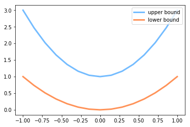

```python
import torch
import torch.nn as nn
import numpy as np
import matplotlib.pyplot as plt

# torch.manual_seed(1)    # reproducible
# np.random.seed(1)

# Hyper Parameters
BATCH_SIZE = 64
LR_G = 0.0001           # learning rate for generator，生成器，新手画家
LR_D = 0.0001           # learning rate for discriminator， 判别器，专业鉴赏家
N_IDEAS = 5             # think of this as number of ideas for generating an art work (Generator)
ART_COMPONENTS = 15     # it could be total point G can draw in the canvas
PAINT_POINTS = np.vstack([np.linspace(-1, 1, ART_COMPONENTS) for _ in range(BATCH_SIZE)])

# show our beautiful painting range
plt.plot(PAINT_POINTS[0], 2 * np.power(PAINT_POINTS[0], 2) + 1, c='#74BCFF', lw=3, label='upper bound')
plt.plot(PAINT_POINTS[0], 1 * np.power(PAINT_POINTS[0], 2) + 0, c='#FF9359', lw=3, label='lower bound')
plt.legend(loc='upper right')
plt.show()
```

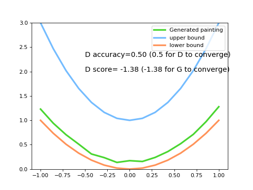

```python
%matplotlib notebook
def artist_works():     # painting from the famous artist (real target)
    a = np.random.uniform(1, 2, size=BATCH_SIZE)[:, np.newaxis]
    paintings = a * np.power(PAINT_POINTS, 2) + (a-1)# 随机生成曲线，在两条曲线之间，算是著名画家画的画
    paintings = torch.from_numpy(paintings).float()
    return paintings

# 弹幕说的对，像autoencoder
G = nn.Sequential(                      # Generator
    nn.Linear(N_IDEAS, 128),            # random ideas (could from normal distribution)
    nn.ReLU(),
    nn.Linear(128, ART_COMPONENTS),     # making a painting from these random ideas
)

D = nn.Sequential(                      # Discriminator
    nn.Linear(ART_COMPONENTS, 128),     # receive art work either from the famous artist or a newbie like G
    nn.ReLU(),
    nn.Linear(128, 1),
    nn.Sigmoid(),                       # tell the probability that the art work is made by artist
)

opt_D = torch.optim.Adam(D.parameters(), lr=LR_D)
opt_G = torch.optim.Adam(G.parameters(), lr=LR_G)

plt.ion()   # something about continuous plotting

for step in range(10000):
    artist_paintings = artist_works()           # real painting from artist
    G_ideas = torch.randn(BATCH_SIZE, N_IDEAS)  # random ideas
    G_paintings = G(G_ideas)                    # fake painting from G (random ideas)，随机生成曲线

    prob_artist0 = D(artist_paintings)          # D try to increase this prob
    prob_artist1 = D(G_paintings)               # D try to reduce this prob

    D_loss = - torch.mean(torch.log(prob_artist0) + torch.log(1. - prob_artist1))# 只有minimize而我们想让它大，所以有负号
    G_loss = torch.mean(torch.log(1. - prob_artist1))

    opt_D.zero_grad()
    D_loss.backward(retain_graph=True)      # reusing computational graph
    opt_D.step()

    opt_G.zero_grad()
    G_loss.backward()
    opt_G.step()

    if step % 50 == 0:  # plotting
        plt.cla()
        plt.plot(PAINT_POINTS[0], G_paintings.data.numpy()[0], c='#4AD631', lw=3, label='Generated painting',)
        plt.plot(PAINT_POINTS[0], 2 * np.power(PAINT_POINTS[0], 2) + 1, c='#74BCFF', lw=3, label='upper bound')
        plt.plot(PAINT_POINTS[0], 1 * np.power(PAINT_POINTS[0], 2) + 0, c='#FF9359', lw=3, label='lower bound')
        plt.text(-.5, 2.3, 'D accuracy=%.2f (0.5 for D to converge)' % prob_artist0.data.numpy().mean(), fontdict={'size': 13})
        plt.text(-.5, 2, 'D score= %.2f (-1.38 for G to converge)' % -D_loss.data.numpy(), fontdict={'size': 13})
        plt.ylim((0, 3));plt.legend(loc='upper right', fontsize=10);plt.draw();plt.pause(0.01)

plt.ioff()
plt.show()
```

## $\S5.\ Others$

### $\S5.1\ Why\ PyTorch\ Is\ Dynamic$

That is to say, before we use PyTorch, Tensorflow builds some kind of quiet graph and the gives inputs, while PyTorch can change the network.

To be precise, PyTorch can change batech_size and time_step at the same time, but Tensorflow can only fix one and run the other using dynamic_rnn.

### $\S5.2\ GPU Acceleration$

Only CUDA from NVIDA can accelerate.

```python
import torch
import torch.nn as nn
import torch.utils.data as Data
import torchvision

# torch.manual_seed(1)

EPOCH = 1
BATCH_SIZE = 50
LR = 0.001
DOWNLOAD_MNIST = False

train_data = torchvision.datasets.MNIST(root='./mnist/', train=True, transform=torchvision.transforms.ToTensor(), download=DOWNLOAD_MNIST,)
train_loader = Data.DataLoader(dataset=train_data, batch_size=BATCH_SIZE, shuffle=True)

test_data = torchvision.datasets.MNIST(root='./mnist/', train=False)

# !!!!!!!! Change in here !!!!!!!!! #
test_x = torch.unsqueeze(test_data.test_data, dim=1).type(torch.FloatTensor)[:2000].cuda()/255.   # Tensor on GPU
test_y = test_data.test_labels[:2000].cuda()


class CNN(nn.Module):
    def __init__(self):
        super(CNN, self).__init__()
        self.conv1 = nn.Sequential(nn.Conv2d(in_channels=1, out_channels=16, kernel_size=5, stride=1, padding=2,),
                                   nn.ReLU(), nn.MaxPool2d(kernel_size=2),)
        self.conv2 = nn.Sequential(nn.Conv2d(16, 32, 5, 1, 2), nn.ReLU(), nn.MaxPool2d(2),)
        self.out = nn.Linear(32 * 7 * 7, 10)

    def forward(self, x):
        x = self.conv1(x)
        x = self.conv2(x)
        x = x.view(x.size(0), -1)
        output = self.out(x)
        return output

cnn = CNN()

# !!!!!!!! Change in here !!!!!!!!! #
cnn.cuda()      # Moves all model parameters and buffers to the GPU.

optimizer = torch.optim.Adam(cnn.parameters(), lr=LR)
loss_func = nn.CrossEntropyLoss()

for epoch in range(EPOCH):
    for step, (x, y) in enumerate(train_loader):

        # !!!!!!!! Change in here !!!!!!!!! #
        b_x = x.cuda()    # Tensor on GPU
        b_y = y.cuda()    # Tensor on GPU

        output = cnn(b_x)
        loss = loss_func(output, b_y)
        optimizer.zero_grad()
        loss.backward()
        optimizer.step()

        if step % 50 == 0:
            test_output = cnn(test_x)

            # !!!!!!!! Change in here !!!!!!!!! #
            pred_y = torch.max(test_output, 1)[1].cuda().data  # move the computation in GPU

            accuracy = torch.sum(pred_y == test_y).type(torch.FloatTensor) / test_y.size(0)
            print('Epoch: ', epoch, '| train loss: %.4f' % loss.data.cpu().numpy(), '| test accuracy: %.2f' % accuracy)


test_output = cnn(test_x[:10])

# !!!!!!!! Change in here !!!!!!!!! #
pred_y = torch.max(test_output, 1)[1].cuda().data # move the computation in GPU

print(pred_y, 'prediction number')
print(test_y[:10], 'real number')
```

```
Epoch:  0 | train loss: 2.3113 | test accuracy: 0.11
Epoch:  0 | train loss: 0.4277 | test accuracy: 0.81
Epoch:  0 | train loss: 0.4817 | test accuracy: 0.87
Epoch:  0 | train loss: 0.2236 | test accuracy: 0.90
Epoch:  0 | train loss: 0.1018 | test accuracy: 0.93
Epoch:  0 | train loss: 0.2851 | test accuracy: 0.94
Epoch:  0 | train loss: 0.2546 | test accuracy: 0.94
Epoch:  0 | train loss: 0.1399 | test accuracy: 0.95
Epoch:  0 | train loss: 0.1425 | test accuracy: 0.95
Epoch:  0 | train loss: 0.1476 | test accuracy: 0.96
Epoch:  0 | train loss: 0.1935 | test accuracy: 0.96
Epoch:  0 | train loss: 0.0602 | test accuracy: 0.96
Epoch:  0 | train loss: 0.0962 | test accuracy: 0.96
Epoch:  0 | train loss: 0.0741 | test accuracy: 0.97
Epoch:  0 | train loss: 0.0196 | test accuracy: 0.97
Epoch:  0 | train loss: 0.0185 | test accuracy: 0.97
Epoch:  0 | train loss: 0.2687 | test accuracy: 0.97
Epoch:  0 | train loss: 0.0490 | test accuracy: 0.97
Epoch:  0 | train loss: 0.1577 | test accuracy: 0.97
Epoch:  0 | train loss: 0.0386 | test accuracy: 0.97
Epoch:  0 | train loss: 0.0629 | test accuracy: 0.98
Epoch:  0 | train loss: 0.0660 | test accuracy: 0.98
Epoch:  0 | train loss: 0.0143 | test accuracy: 0.97
Epoch:  0 | train loss: 0.1762 | test accuracy: 0.98
tensor([7, 2, 1, 0, 4, 1, 4, 9, 5, 9], device='cuda:0') prediction number
tensor([7, 2, 1, 0, 4, 1, 4, 9, 5, 9], device='cuda:0') real number
```

Woc, GPU is indeed faster!

### $\S5.3\ Overfitting$

1. method 1: increase data
2. method 2: regulariztion
   - $L_1: cost = (Wx-real\ y)^2 + abs(W)$
   - $L_2: cost = (Wx-real\ y)^2 + W^2$
   - ...
3. method 3 (NN only): drop out
   - each time ignore some neutrons, so NN will not rely on some big weight

[figure not shown]

```python
import torch
import matplotlib.pyplot as plt
%matplotlib notebook

# torch.manual_seed(1)    # reproducible

N_SAMPLES = 20
N_HIDDEN = 300

# training data
x = torch.unsqueeze(torch.linspace(-1, 1, N_SAMPLES), 1)
y = x + 0.3*torch.normal(torch.zeros(N_SAMPLES, 1), torch.ones(N_SAMPLES, 1))

# test data
test_x = torch.unsqueeze(torch.linspace(-1, 1, N_SAMPLES), 1)
test_y = test_x + 0.3*torch.normal(torch.zeros(N_SAMPLES, 1), torch.ones(N_SAMPLES, 1))

# show data
plt.scatter(x.data.numpy(), y.data.numpy(), c='magenta', s=50, alpha=0.5, label='train')
plt.scatter(test_x.data.numpy(), test_y.data.numpy(), c='cyan', s=50, alpha=0.5, label='test')
plt.legend(loc='upper left')
plt.ylim((-2.5, 2.5))
plt.show()
```

```python
net_overfitting = torch.nn.Sequential(
    torch.nn.Linear(1, N_HIDDEN),
    torch.nn.ReLU(),
    torch.nn.Linear(N_HIDDEN, N_HIDDEN),
    torch.nn.ReLU(),
    torch.nn.Linear(N_HIDDEN, 1),
)

net_dropped = torch.nn.Sequential(
    torch.nn.Linear(1, N_HIDDEN),
    torch.nn.Dropout(0.5),  # drop 50% of the neuron
    torch.nn.ReLU(),
    torch.nn.Linear(N_HIDDEN, N_HIDDEN),
    torch.nn.Dropout(0.5),  # drop 50% of the neuron
    torch.nn.ReLU(),
    torch.nn.Linear(N_HIDDEN, 1),
)

print(net_overfitting)  # net architecture
print(net_dropped)
```

```
Sequential(
  (0): Linear(in_features=1, out_features=300, bias=True)
  (1): ReLU()
  (2): Linear(in_features=300, out_features=300, bias=True)
  (3): ReLU()
  (4): Linear(in_features=300, out_features=1, bias=True)
)
Sequential(
  (0): Linear(in_features=1, out_features=300, bias=True)
  (1): Dropout(p=0.5)
  (2): ReLU()
  (3): Linear(in_features=300, out_features=300, bias=True)
  (4): Dropout(p=0.5)
  (5): ReLU()
  (6): Linear(in_features=300, out_features=1, bias=True)
)
```

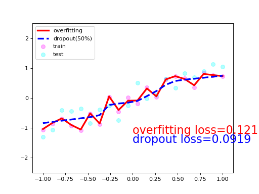

```python
optimizer_ofit = torch.optim.Adam(net_overfitting.parameters(), lr=0.01)
optimizer_drop = torch.optim.Adam(net_dropped.parameters(), lr=0.01)
loss_func = torch.nn.MSELoss()

plt.ion()   # something about plotting

for t in range(500):
    pred_ofit = net_overfitting(x)
    pred_drop = net_dropped(x)
    loss_ofit = loss_func(pred_ofit, y)
    loss_drop = loss_func(pred_drop, y)

    optimizer_ofit.zero_grad()
    optimizer_drop.zero_grad()
    loss_ofit.backward()
    loss_drop.backward()
    optimizer_ofit.step()
    optimizer_drop.step()

    if t % 10 == 0:
        # change to eval mode in order to fix drop out effect，以前是train模式
        net_overfitting.eval()
        net_dropped.eval()  # parameters for dropout differ from train mode

        # plotting
        plt.cla()
        test_pred_ofit = net_overfitting(test_x)
        test_pred_drop = net_dropped(test_x)
        plt.scatter(x.data.numpy(), y.data.numpy(), c='magenta', s=50, alpha=0.3, label='train')
        plt.scatter(test_x.data.numpy(), test_y.data.numpy(), c='cyan', s=50, alpha=0.3, label='test')
        plt.plot(test_x.data.numpy(), test_pred_ofit.data.numpy(), 'r-', lw=3, label='overfitting')
        plt.plot(test_x.data.numpy(), test_pred_drop.data.numpy(), 'b--', lw=3, label='dropout(50%)')
        plt.text(0, -1.2, 'overfitting loss=%.4f' % loss_func(test_pred_ofit, test_y).data.numpy(), fontdict={'size': 20, 'color':  'red'})
        plt.text(0, -1.5, 'dropout loss=%.4f' % loss_func(test_pred_drop, test_y).data.numpy(), fontdict={'size': 20, 'color': 'blue'})
        plt.legend(loc='upper left'); plt.ylim((-2.5, 2.5));plt.pause(0.1)

        # change back to train mode
        net_overfitting.train()
        net_dropped.train()

plt.ioff()
plt.show()
```